# PSTAT194 CS Section 8

Yue(Yuri) He

Spring 2022

```r
library(ggplot2)
library(dplyr)
library(tidyr)
```

## HW3 Exercise 1

Design an algorithm to simulate from a Geometric(p) (where x is the number of failures until the first success) distribution via the inverse transform method. (Hint: Recall that Geometric random variables are just the number of Bernoulli random variables with the same parameter p until you get a success. So just focus on simulating n Bernoulli variables and then you can transform to Geometric ones.)

**What is x value if simulated Bernoulli trials are:**

0 0 1: x=2

1: x=0

0 0 0 0 0 1: x=5

**ALG**

Step1: Sample Bernoulli data points, and stop once reach the first 1. (Inverse CDF method for Bernoulli distribution)

Step2: Count how many 0s before the first 1, set this equals to x.

Step3: Repeat Step1 and 2 n times to have n sample points from Geometric distribution

**How to use inverse CDF method to generate Bernoulli sample:**

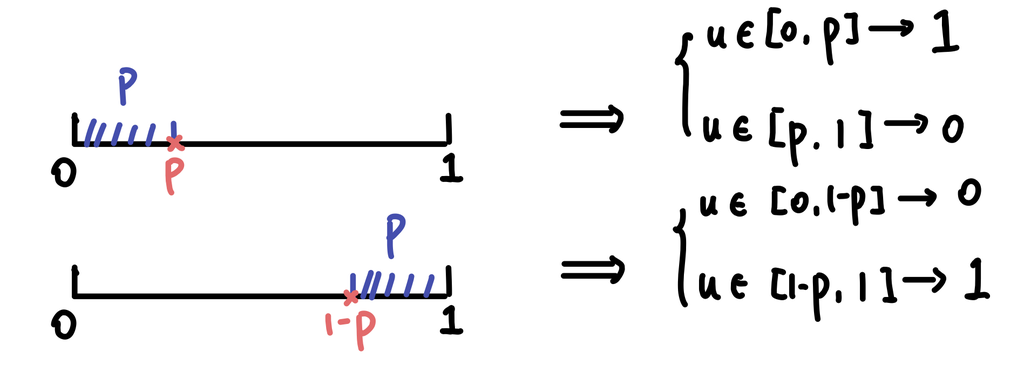

```r
set.seed(3)
geo <- function(n, p){
  sample <- c() #An empty vector for our results
  for(i in 1:n){
      u <- runif(1)
      j <- 0 #Counter; so far, there have been 0 failures
      while(u>p){
        u <- runif(1)
        j <- j+1
      }
      sample[i] <- j #The number of trials it took to get a success
  }
  return(sample)
}

sample <- geo(1000,0.4)
mean(sample)
```

```
## [1] 1.551
```

Theoretical value: $\frac{1-p}{p}=\frac{0.6}{0.4}=1.5$

## Bayesian analysis using MC integration

### Bayes’ Theorem

Focus on modeling, assume data was generated from a statistical model, with model parameters are random instead of fixed.

$$p(\theta|x)=\frac{p(x|\theta)p(\theta)}{p(x)}\propto p(x|\theta)p(\theta) \quad\left(P(A|B)=\frac{P(A \cap B)}{P(B)}\right)$$
where

- $p(\theta|x)$: posterior
- $p(x|\theta)$: likelihood or model, also denote as $f(x|\theta)$ or $L(\theta|x)$
- $p(\theta)$: prior (normally denote as $\pi(\theta)$ in Bayesian analysis)
- $p(x)=\int p(x|\theta)p(\theta) d\theta$ marginal liklihood of data

### Prior

#### Conjugate Prior

A conjugate prior is a family of probability distribution such that the posterior distribution is the same family of probability as the prior distribution.

Ex. Suppose $X_1,\ldots,X_n$ are $n$ independent and identical distributed (i.i.d.) R.V.s from $N(\mu,\sigma^2)$, each having an umknown mean $\mu$ and known variance $\sigma^2$. Assume the prior for $\mu$ follows a normal distribution $N(m,C)$, where the prior mean $m$ and variance $C$ are known. What is the posterior mean for $\mu$ ($E[\mu|\mathbf{x}]$)?

Based on question, Likihood is
$$p(\mathbf{x}|\mu)=p(X_1=x_1,...X_n=x_n|\mu)=\prod_{i=1}^n\{\frac{1}{\sqrt{2\pi\sigma^2}}e^{-\frac{1}{2\sigma^2}(x_i-\mu)^2}\}$$
The prior is
$$\pi(\mu)=\frac{1}{\sqrt{2\pi C}}e^{-\frac{1}{2C}(\mu-m)^2}$$
Then, by Bayes’ Theorem

$$\begin{align}
p(\mu|\mathbf{x}) &\propto p(\mathbf{x}|\mu)\pi(\mu)\\
&= \prod_{i=1}^n\left\{\frac{1}{\sqrt{2\pi\sigma^2}}e^{-\frac{1}{2\sigma^2}(x_i-\mu)^2}\right\} \frac{1}{\sqrt{2\pi C}}e^{-\frac{1}{2C}(\mu-m)^2}\\
&\propto e^{-\frac{1}{2\sigma^2}\sum_{i=1}^n(x_i-\mu)^2}e^{-\frac{1}{2C}(\mu-m)^2}\\
&= exp\left\{-\frac{1}{2\sigma^2}(\sum_{i=1}^n x_i^2-2\mu\sum_{i=1}^n x_i+n\mu^2)-\frac{1}{2C}(\mu^2-2\mu m+m^2)\right\}\\
&\propto exp\left\{-\frac{1}{2\sigma^2}(-2\mu\sum_{i=1}^n x_i+n\mu^2)-\frac{1}{2C}(\mu^2-2\mu m)\right\}\\
&= exp\left\{-\frac{1}{2\sigma^2C}\left((nC+\sigma^2)\mu^2-2(nC\bar{x}+\sigma^2m)\mu\right)\right\}\\
&\propto exp\left\{-\frac{1}{2 \frac{\sigma^2C}{nC+\sigma^2}}\left(\mu-\frac{nC\bar{x}+\sigma^2m}{nC+\sigma^2}\right)^2\right\}
\end{align}$$

This is proportional to Normal distribution, thus, $\mu|\mathbf{x}\sim N(m_n,C_n)$ where
$$m_n = E[\mu|\mathbf{x}]=\frac{nC\bar{x}+\sigma^2m}{nC+\sigma^2}=\frac{C}{C+\sigma^2/n}\bar{x}+\frac{\sigma^2/n}{C+\sigma^2/n}m$$
weighted average of data and believe, and
$$C_n=\frac{\sigma^2C}{nC+\sigma^2}=(\frac{n}{\sigma^2}+\frac{1}{C_0})^{-1}$$

#### Subjective Prior vs. Objective Prior

Subjective Bayes emphasize the use of a subjective prior, and statisticians should sit down with a domian expert to elicit an appropriate prior for the study.

Objective Bayes uses the objective/default prior, such that the inference is (at least) not biased. (Bayes and Laplace are the earliest scholars to consider objectivity in Byesian study.)

### HW4 Exercise 3

Suppose $X_1,\ldots,X_n$ are $n$ independent and identical distributed random variables from $Exp(\theta)$, where $\theta$ is the unknown parameter. So,
$$f(x|\theta) = \theta \; e^{-\theta x}, \quad x \ge 0.$$

We assume the prior distribution on $\theta$ is the Gamma distribution ($Gamma(3,2)$).
$$g(\theta) = 4 \theta^2 e^{-2\theta}, \quad x \ge 0.$$

a). Write down the posterior distribution of $\theta$, $g(\theta|X)$.

Liklihood is
$$f(\mathbf{x}|\theta)=f(X_1=x_1,...X_n=x_n|\theta)=\prod_{i=1}^n\theta e^{-\theta x_i}=\theta^ne^{-\theta\sum_{i=1}^nx_i}$$

Then, by Bayes’ Theorem

$$\begin{align}
g(\theta|\mathbf{x}) &\propto f(\mathbf{x}|\theta)g(\theta)\\
&=\theta^ne^{-\theta\sum_{i=1}^nx_i}4 \theta^2 e^{-2\theta}\\
&\propto \theta^{n+2}e^{-\theta(2+\sum_{i=1}^nx_i)}
\end{align}$$

This is proportional to a Gamma distribution, thus $\theta|\mathbf{x} \sim Gamma(n+3,2+\sum_{i=1}^nx_i)$, and
$$g(\theta|\mathbf{x})=\frac{(2+\sum_{i=1}^nx_i)^{n+3}}{\Gamma(n+3)}\theta^{n+2}e^{-\theta(2+\sum_{i=1}^nx_i)}$$

b). Suppose $n=6$ and we observe that $x_1=0.4, x_2=1.1, x_3=0.2, x_4=1.6, x_5=1.4, x_6=0.9$. Estimate the posterior mean of $\theta$.

Since know $\theta|\mathbf{x} \sim Gamma(n+3,2+\sum_{i=1}^nx_i)=Gamma(9,7.6)$, then $E[\theta|\mathbf{x}]=\frac{9}{7.6}=1.184$

Now for MC approach:

Case 1: can recognize the posterior distribution (& easy to sample from)

$E[\theta|\mathbf{x}]=\int\theta g(\theta|\mathbf{x})d\theta$

```r
set.seed(3)
m <- 10000
theta <- rgamma(m,9,7.6)
mean(theta)
```

```
## [1] 1.183651
```

Case 2: can’t recognize the posterior distribution (/not easy to sample from)

$E[\theta|\mathbf{x}]=\int\theta g(\theta|\mathbf{x})d\theta=\frac{\int \theta f(\mathbf{x}|\theta)g(\theta)d\theta}{\int f(\mathbf{x}|\theta)g(\theta)d\theta}$

```r
set.seed(3)
m <- 10000
x <- c(0.4, 1.1, 0.2, 1.6, 1.4, 0.9) # observed data
n = length(x)

theta <- rgamma(m,3,2)             # theta from prior distribution
f <- (theta^n)*exp(-theta*sum(x))  # compute the likelihood function

post.mean <- mean(theta*f)/mean(f) # estimate the posterior mean
post.mean
```

```
## [1] 1.187654
```

c). Suppose $n=6$ and we observe that $x_1=0.4, x_2=1.1, x_3=0.2, x_4=1.6, x_5=1.4, x_6=0.9$. 1) Design an acceptance-rejection sampling algorithm to generate $10000$ (accepted) samples of $\theta$ from the posterior distribution of $\theta$. Use $g(\theta)$ as proposal distribution. 2) Implement your acceptance-rejection sampling algorithm with R code. Plot the histogram of your generated sample.

Steps for A-R Method: (For this example target distribution is $g(\theta|\mathbf{x})$ and proposal distribution is $g(\theta)$)

1. Find M: since $g(\theta|\mathbf{x}) \propto f(\mathbf{x}|\theta)g(\theta)$, then $M=sup_{\theta}\frac{g(\theta|\mathbf{x})}{g(\theta)}=sup_{\theta}f(\mathbf{x}|\theta)$
2. Draw a sample point $\theta$ from prior(proposal) distribution $g(\theta)$
3. Generate a random number $u \in[0,1]$
4. Decide whether accept $\theta$ from step 1 as a sample point from $g(\theta|\mathbf{x})$ by checking condition $u<\frac{f(\mathbf{x}|\theta)}{M}$; Yes—accept, No—reject
5. Repeat steps 2-3 until have enough sample

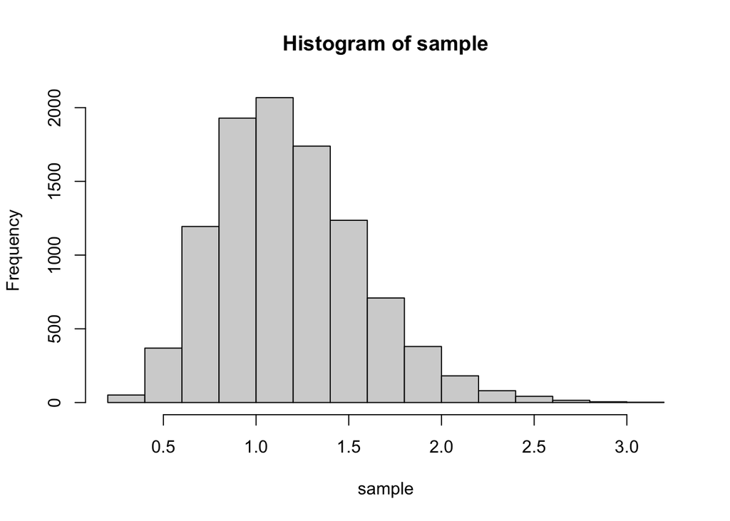

```r
set.seed(3)
N = 10000
i = 1
sample= c()

likelihood <- function(theta){theta^n * exp(-theta*sum(x))}
M = optimize(likelihood, c(0,5), maximum = TRUE)$objective

while(i <= N){
  theta = rgamma(1,3,2)
  u = runif(1)
  if(u < likelihood(theta)/M){
    sample[i] = theta
    i=i+1
  }
}
hist(sample)
```

```r
mean(sample)
```

```
## [1] 1.181786
```

## MC for hypothesis test

Suppose that we wish to test a hypothesis concerning a parameter hat lies in a parameter space $\Theta$. The hypotheses of interest are
$$H_0: \theta \in \Theta_0 \quad vs \quad H_1: \theta \in \Theta_1$$
Two types of error can occur:

- Type I error: if the null hypothesis is rejected when in fact the null hypothesis is true. $P(\text{reject }H_0| H_0 \text{ is true})$
- Type II error: if the null hypothesis is not rejected when in fact the null hypothesis is false. $P(\text{doesn't reject }H_0| H_1 \text{ is true})$

### Power of a Test

Power function $\pi: \Theta \rightarrow [0,1]$, which is the probability $\pi(\theta)$ of rejecting $H_0$ given that the true value of the parameter is $\theta$.

The power of a test is the probability of correctly rejecting the null hypothesis, $P(\text{reject }H_0| H_1 \text{ is true})=\pi(\theta_1)$.

Thus, for a given $\theta \in \Theta_1$, the prob. of Type II error is $1-\pi(\theta_1)$. Ideally, we would prefer a test with low prob. of error. Since Type I error is controlled by the significance level $\alpha$, then comparing tests for the same hypotheses at same significance level, we are interested in comparing power of the tests.

MC estimate of the power of a test:

Step1: Select a particular value of the parameter $\theta \in \Theta_1$.

Step2: Generate random sample $x_1,\dots,x_n$ under the conditions of the alternative $\theta_1$.

Step3: Compute the test statistic from the sample.

Step4: Record the test decision: set $I = 1$ if $H_0$ is rejected at significance level $\alpha$, and otherwise set $I = 0$.

Step5: Repeat Step 1-4 for total m $\theta \in \Theta_1$, and compute the proportion of significant tests $\pi(\theta_1) =\frac{1}{m}\sum_{j=1}^m I_j$

**HW4 Exercise 5**

Plot the empirical power curve for the t-test in Example 6.9, changing the alternative hypothesis to $H_1:\mu \neq 500$, and keeping the significance level $\alpha = 0.05$.

Suppose that $X_1,\ldots,X_{20}$ is a random sample from a $N(\mu,\sigma^2)$ distribution, $\sigma=100$. Test $H_0 : \mu = 500 \quad H_1 : \mu > 500 \text{ at } \alpha = 0.05$. Under the null hypothesis,
$$T^* = \frac{\bar{X}-500}{S/\sqrt{20}}\sim t(19)$$
where t(19) denotes the Student t distribution with 19 degrees of freedom.

Step1: Select a particular value of the parameter $\theta \in \Theta_1$, i.e $\mu \neq 500$.

Step2: Generate random sample $x_1,\dots,x_{20}$ under the conditions of the alternative $\mu_1$.

Step3: Compute the test statistic from the sample.

Step4: Record the test decision: set $I = 1$ if $H_0$ is rejected at significance level $\alpha$, and otherwise set $I = 0$.

Step5: Repeat Step 1-4 for $m=1000$ times, and compute the proportion of significant tests $\pi(\mu_1) =\frac{1}{1000}\sum_{j=1}^{1000} I_j$

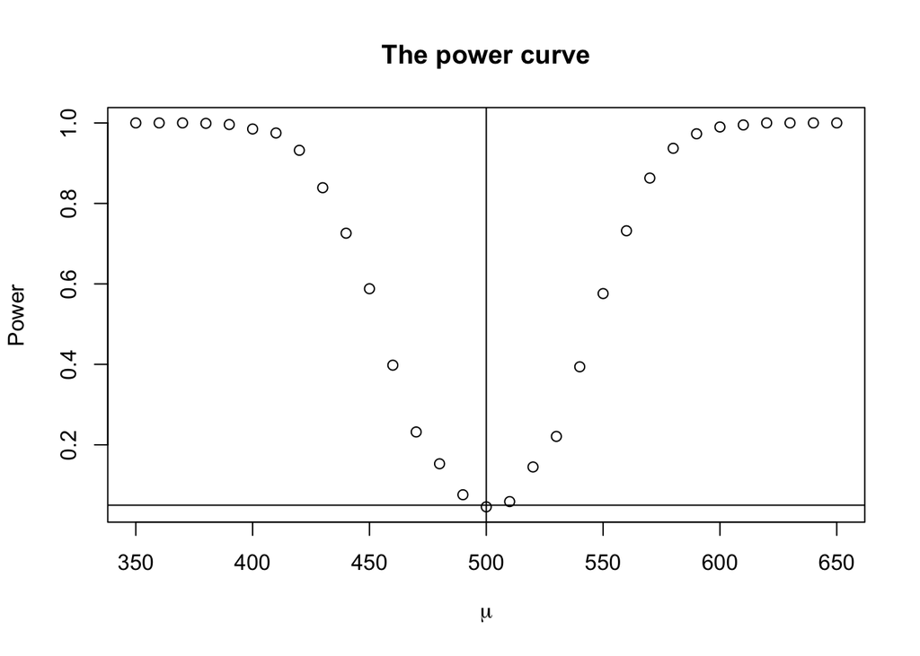

```r
n <- 20
m <- 1000  #number of replicates
mu0 <- 500
sigma <- 100
mu <- c(seq(350, 650, 10)) #Alternatives Space
M <- length(mu)
power <- c()
for (i in 1:M){
  mu1 <- mu[i]
  pvalues <- replicate(m, expr = {
    #simulate under alternative mu1
    x <- rnorm(n, mean = mu1, sd = sigma)
    ttest <- t.test(x,
    alternative = "two.sided", mu = mu0)
    ttest$p.value })
  power[i] <- mean(pvalues <= .05) # P-value less than sig. level, reject null
}
plot(mu, power, main="The power curve", xlab=bquote(mu), ylab="Power")
abline(v = mu0, lty = 1)
abline(h = .05, lty = 1)
```